# Project: Exploring Seabird Data

## Data Source:

> The data I collected is coming from a recent TidyTuesday repository. It is a collection of seabird data from 1969 to 1990, and it includes four different datasets. One for the observations of birds by species, one for the ship details/traveling conditions of the record ID, one for sea states, and one for beaufort scales.

## Data Description:

> The birds dataset includes the record ID (numeric), bird name and scientific name as string variables, bird count (numeric), and behaviors (following ship, sitting on water, feeding) as boolean (TRUE/FALSE) values. The ships data set includes corresponding information on the record ID (numeric), date, time, latitude/longitude, activity, atmospheric/barometric measurements, season, and observer. The sea states data set includes the sea state class (corresponding to the ships data set) sea state verbal description, and wave meters min and waves meter max. The beaufort scale data set includes the wind speed class correpsonding to the ships data set (discrete), wind speed verbal description, and the wind speed knots min/max. With this data, I am seeking to answer the following mini-research questions.

## Research Questions:

> What season are all seabirds most and least frequently observed in the Eastern hemisphere?

> What sea conditions are seabirds most frequently spotted (sea state)?

## Data Cleaning

To clean the data, I first examined all four datasets, and found that only the “birds” and “ships” data would be meaningful for my analysis. I then selected only relevant variables to use from the birds data, such as the record id, observation id, and count (total number of birds observed per observation). I then found a matching variable in the birds and ships data sets and used it to join both together. This gave me additional metadata associated with each observation that pertained to my research questions. Next, I had to convert two variable (sea state and wind state) to factors, so I could treat them as distinct levels (sea state 1, 2, 3, etc.) instead keeping them on a continuous scale.

## Visualization 1 - Seasons Barplot

This bar plot investigates if there are any seasons where seabirds are observed the most across the entire time series of observations from 1969-1990. The x-axis is mapped to season (winter, spring, summer, fall), and the y-axis is the total count of all birds. From here we can clearly see that seabirds are most frequently observed in the spring, followed closely by summer. This makes sense as rising sea and coastal temperatures in spring, along with increased sunlight availability, can lead to more abundance of phytoplankton, causing a trophic cascade of food/fish availability in the water column for seabirds. Migratory seabirds follow open-ocean hunting patterns year-round, but it may be easier to observe these behaviors in the spring and summer when such resources are abundant for fish, as compared to the winter and autumn seasons.

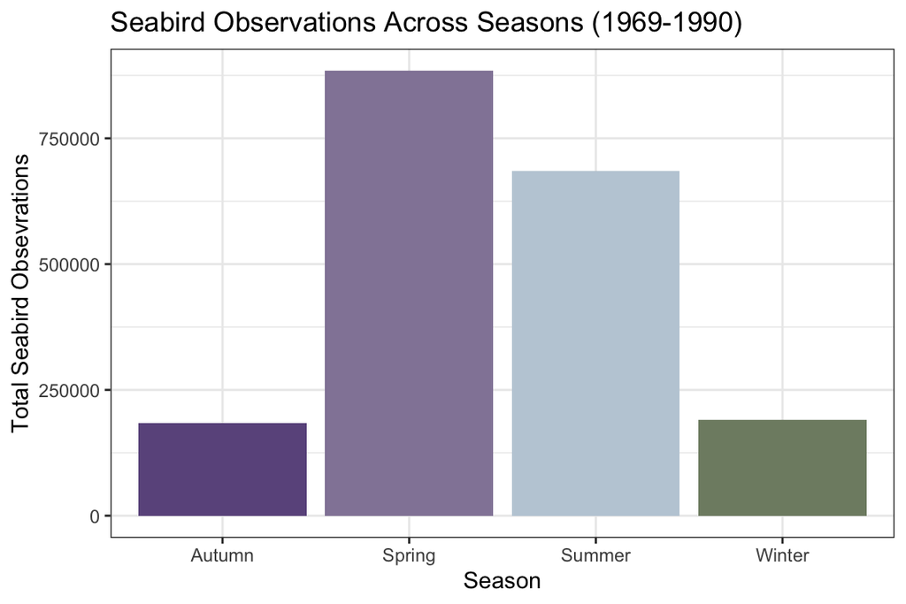

Figure 1: Bar plot comparing the total counts for seabirds across all species by calendar season. Data: TidyTuesday (Github)

## Visualization 2 - Sea Conditions Heatmap

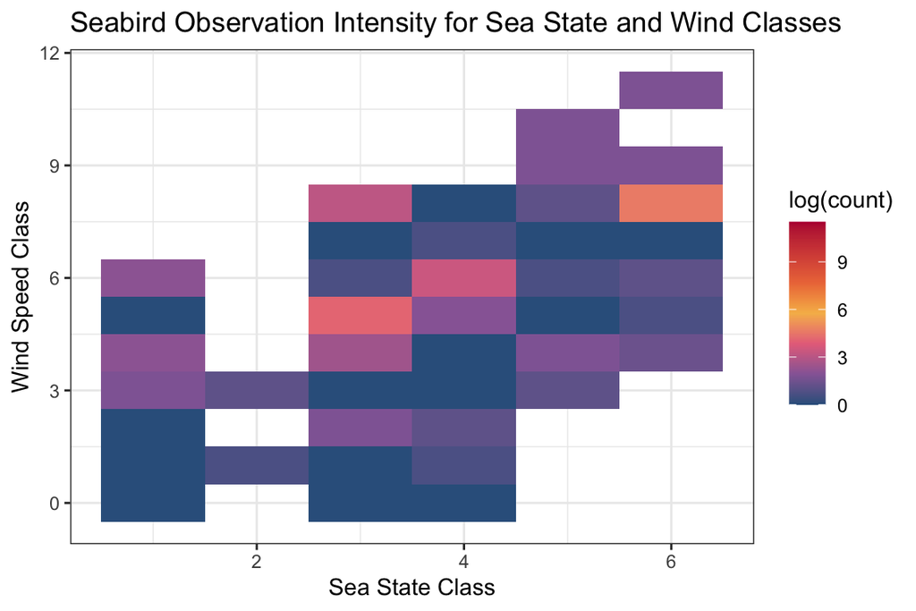

Figure 2: Heatmap displaying the intensity of seabird observations by sea state class and wind state class. Data: TidyTuesday (Github)